[figure not shown]

,

**Mineração de dados e apresentação dos dados em nuvem de palavras**  
**Pacotes: tm(text mining) e wordcloud2**

**Integrantes:**  
- Bernardo Souza Scaldaferri  
- Denise Alves dos Santos  
- Ingrid Raquel Silva  
- Klara Narumi de Hamada Maia  
**Professor:**  
Cristiano de Carvalho Santos  
**Disciplina:**  
Pacotes Estatísticos

Departamento de Estatística  
Belo Horizonte,13 de Outubro de 2020

# Introdução

Esse relatório visa cumprir os objetivos do Trabalho 2 da disciplina de Pacotes Estatísticos do semestre 2020/1 da Universidade Federal de Mians Gerais. Dessa forma, será abordado os pacotes tm(text mining) e wordcloud2.  
Nesse trabalho será utilizado a análise do discurso de Ulysses Guimarães: https://www.bbc.com/portuguese/brasil-45750071 [Íntegra do discurso de 05 de outubro de 1988](https://www.camara.leg.br/radio/programas/277285-integra-do-discurso-presidente-da-assembleia-nacional-constituinte-dr-ulysses-guimaraes-10-23/)  
Observação: baixe o arquivo pdf com a transcrição do discurso e deixe, de preferência, no mesmo diretório de análise do R

# tm(text mining)

Funções utilizadas:

stopwords, tem como argumento o kind, que seleciona a língua do texto, e retorna uma lista com as stopwords da língua escolhida.

RemovePunctuation, remove caracteres especiais em vetores de carácteres ou documentos de texto, possuí dois argumentos, preserve_intra_word_contractions, que define se contrações de palavras serão mantidas ou removidas (isso é mais importante para língua inglesa), e preserve_intra_word_dashes, que define se hifens dentro das palavras serão mantidos.

RemoveWords, uma função que tem como argumento uma lista de palavras, e que as remove de um vetor de carácteres ou documento de texto.

StripWhitespace, uma função que remove os espaços “extras” (sempre deixando um) entre palavras em vetores de carácteres ou documentos de texto.

VectorSource, uma função que transforma os textos de um vetor de textos em documentos.

Corpus, função que transforma um vetor de documentos em um corpus (formato base para o textmining).

TermDocumentMatrix, função que transforma um corpus em matriz.

FindAssocs, função que usa métodos analíticos e matriciais para encontrar relações entre os termos da matrix do corpus.

RemoveSparseTerms, função que remove elementos de uma matriz do corpus que sejam menos esparsos que o valor especificado no argumento sparse.

Inspect, dá informações detalhadas sobre um corpus, dada a sua matriz.

# wordcloud2

Os argumentos do wordcloud2 são:  
- data: os dados para gerar a nuvem de palavras  
- size: tamanho da fonte - minSize:sequência de string do subtítulo  
- gridSize:tamanho da grade em pixels para marcar a disponibilidade da tela  
- fontFamily: fonte  
- fontWeight: peso da fonte  
- color: cor do texto, exemplos: ‘random-dark’;‘random-light’  
- backgroundColor: cor do fundo  
- minRotation: a rotação mínima (em rad) que o texto deve girar  
- maxRotation: a rotação máxima (em rad) que o texto deve girar  
- shuffle: misture os pontos a serem desenhados  
- rotateRatio: probabilidade de rotação da palavra  
- shape: forma da “nuvem”, exemplos:  
- circle  
- cardioid  
- diamond  
- triangle-forward  
- triangle  
- pentagon  
- star  
- ellipticity: grau de "achatamento  
- widgetsize: tamanho dos widgets  
- figPath: caminho para uma figura  
- hoverFunction: retorno de chamada para chamar quando o cursor entra ou sai de uma região ocupada por uma palavra

# Tutorial

## Preparação do ambiente

Definição do diretório

```r
# Código para saber o diretório atual
getwd()
# Código para definir o diretório de interesse
# Essa parte depende de cada computador
# Para saber como escrever o seu diretório: Files ->ir até a pasta -> More -> Set As Working Directory
#setwd("~/Downloads/tp2")
# Caso não queira usar o setwd é só colocar todos os documentos usados no meu diretório
# Código para limpar o ambiente
rm(list = ls(all=T))
options(scipen=999)
```

Pacotes utilizados durante o processo:  
Instalação e chamada dos pacotes

```r
listofPackages <- c("tidyverse","wordcloud2", "tm", "tidytext", "pdftools", "rvest", "readr")
packages <- function(listofPackages){
  new.packages <- listofPackages[!(listofPackages %in% installed.packages()[, "Package"])]
  if (length(new.packages))
    install.packages(new.packages, dependencies = TRUE)
  sapply(listofPackages, require, character.only = TRUE)
}

lapply(listofPackages, library, character.only = TRUE)
```

Teste se os pacotes de interesse foram instalados

```r
packages(listofPackages)
```

```
##  tidyverse wordcloud2         tm   tidytext   pdftools      rvest      readr
##       TRUE       TRUE       TRUE       TRUE       TRUE       TRUE       TRUE
```

## Coleta dos dados

É necessário escolher um documento para fazer a análise.  
Importação do arquivo pdf

```r
pdf_info("Ulysses_Constituinte.pdf")
ulysses <- pdf_text("Ulysses_Constituinte.pdf")
```

```r
ulysses <- ulysses[c(1,2)]
ulysses <- paste(ulysses, collapse = " ")
```

É interessante exportar para o diretório o arquivo em formato txt para verificar se tudo está em ordem, dessa forma, utiliza o código abaixo para gravar o arquivo em formato txt.

```r
write_lines(ulysses, "ulysses.txt")
```

Selecione o discurso

```r
texto <- read_csv("ulysses.txt", col_names = FALSE) # conteúdo na linha 11
novo_texto <- texto[11,1]
```

Leia o arquivo txt e o converta em vetor:

```r
novo_texto <- as.matrix(novo_texto)
novo_texto <- as.vector(novo_texto)
```

Nesse texto, existe uma referência no final da primeira página, para tirar é utilizado:

```r
novo_texto <- str_replace(novo_texto, "https://www.camara.leg.br/radio/programas/277285-integra-do-discurs…nte-da-assembleia-nacional-constituinte-dr-ulysses-guimaraes-10-23/        Página 1 de 3
 Portal da Câmara dos Deputados                                                                                                               02/10/2020 23'15", "")
write_lines(novo_texto, "ulysses.txt")
```

Parta o discurso em unidades textuais

```r
#Código para fazer a leitura dos parágrafos
novo_origem <- read_lines("ulysses.txt")
#Código para apresentar a estrutura criada
str(novo_origem)
# Código para criar contagem 10 em 10
dez <- rep(1:ceiling(length(novo_origem)/10), each = 10)
str(dez)
# Cógio para ficar com o mesmo número de parágrafos existente no texto inicial
dez <- dez[1:length(novo_origem)]
str(dez)
novo_texto <- cbind(dez, novo_origem) %>% data.frame()
novo_texto <- aggregate(formula = novo_origem ~ dez,
                        data = novo_texto,
                        FUN = paste,
                        collapse = " ")
# Código para transformar em matriz
novo_texto <- novo_texto %>% select(novo_origem) %>% as.matrix
dim(novo_texto)
```

### Pré-processamento

É necessário fazer uma limpeza do documento de interessante para que a análise dos dados não tenha interferência.  
Retirada de stopwords - palavras de conexão comuns usados em cada idioma, por isso deve escolher qual linguagem cada texto de interesse se quer retirar.

```r
#Código para carregar o stopwords em língua portuguesa do pacote tm (203 no total)
sw_pt_tm <- stopwords('portuguese')
#Código para converter os stopwords em dataframe
sw_pt_tm <- data.frame(sw_pt_tm)
#Código para renomerar a variável
sw_pt_tm <- rename(sw_pt_tm, palavra = sw_pt_tm)
#Código para acrescentar palavras no stopwords do pacote tm
stopwords_personal <- tibble(palavra = c("é", "ainda", "alguns", "pra"))

#stop_words_pt <- c(stopwords("pt"), "é", "ainda", "alguns", "pra")
```

Extra: links para listas alternativas de stopwords em português:  
- https://www.ranks.nl/stopwords/brazilian  
- http://miningtext.blogspot.com/2008/11/listas-de-stopwords-stoplist-portugues.html  
- https://gist.github.com/alopes/5358189  
Funções do pacote tm para limpeza do texto:

```r
# Código para eliminar caracteres especiais
novo_texto <- gsub("[[:cntrl:]]", " ", novo_texto)
# Código para deixar tudo minúsculo
novo_texto <- tolower(novo_texto)
# Código para remover pontuação
novo_texto <- removePunctuation(novo_texto)
# Código para Remover os espaços em branco
novo_texto <- stripWhitespace(novo_texto)
# Código para renomear a variável
novo_texto <- tibble(texto = novo_texto)
# Código para tokenizar as palavras e eliminar as palavras de conexão
texto_palavras <- novo_texto %>%
  unnest_tokens(palavra, texto, strip_numeric = TRUE) %>%
  count(palavra, sort = TRUE)
palavras_freq <- texto_palavras %>%
  anti_join(stopwords_personal) %>%
  anti_join(sw_pt_tm)
```

### Indexação

```r
# Código para observar as 10 palavras mais frequentes por meio de um gráfico
grafico_palavras <- palavras_freq %>%
  top_n(10) %>%
  ggplot(aes(y = reorder(palavra, n), x = n)) +
  geom_col(fill = "#EEBBAA") +
  labs(y = NULL,
       x = "frecuencia",
       title = "As 10 palavras mais frequentes") +
  theme_minimal()
# Código do wordcloud 2 para fazer uma nuvem de palavras
wordcloud2(data = palavras_freq, size = 0.5)
```

[interactive chart not shown]

### Mineração

Cálculo de inferência e extração do conhecimento

```r
novo_texto <- as.matrix(novo_texto)
novo_texto <- as.vector(novo_texto)
# novo_texto - sem pontuação nem palavras de conexão
```

```r
corpus_source <- VectorSource(novo_texto)
novo_corpus <- Corpus(corpus_source)
```

Mapeando o Corpus indicando que é uma matriz de termos para fazer associação entre palavras

```r
novo_tdm <- TermDocumentMatrix(novo_corpus)
#terms == número de palavras distintas no corpus. documents: quantos textos tomados
```

```r
findAssocs(novo_tdm, "constituição", 0.7)
# associaçã mínima de 0.7 com a palavra chave
```

[output not shown]

```r
findAssocs(novo_tdm, terms = c("sociedade", "nação", "estado"), corlimit = .70)
```

[output not shown]

```r
inspect(removeSparseTerms(novo_tdm, 0.4))
```

[output not shown]

```r
novo_new <- removeSparseTerms(novo_tdm, sparse = .75)
# quantos termos originalmente
novo_tdm
# quantos termos ficaram
novo_new
```

[output not shown]

```r
novo_tdm$nrow # para ver o número de linhas/ palavras do corpus original
novo_new$nrow # para ver o número de linhas palavras do corpus reduzido
```

[output not shown]

Matriz de distâncias

```r
# Para realizar as operações transformar em matriz
novo_new <- novo_new %>% as.matrix()
```

Existe a função ‘scale’ ela realiza a padronização a partir de cada coluna.  
Muito util de cada coluna for um texto como uma unidade completa  
No caso vamos usar a média por linha para ver a associação das palavras por linha

```r
novo_new <- novo_new / rowSums(novo_new)
```

Matriz de distâncias com distâncias euclidianas

```r
novo_dist <- dist(novo_new, method = "euclidian")
#novo_dist
```

Agrupamento hierárquico

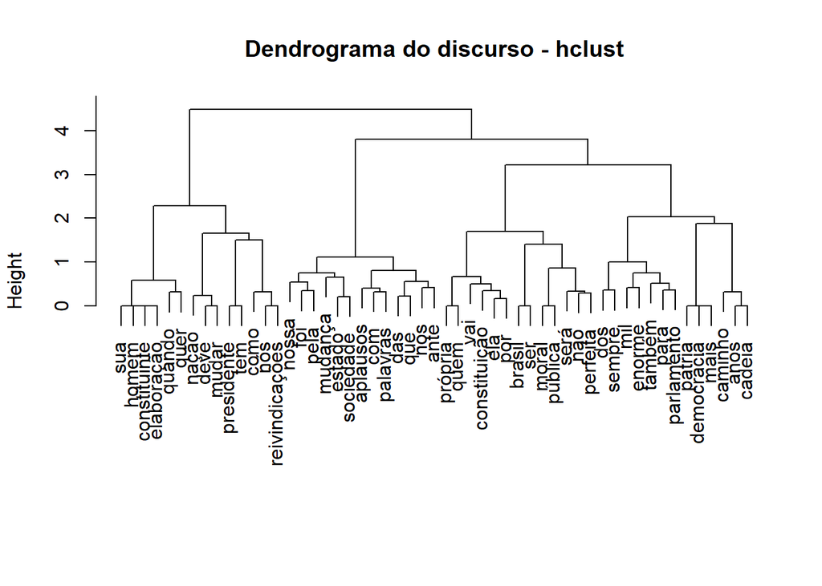

```r
novo_hclust <-  hclust(novo_dist, method = "ward.D")
# Código para geraar o gráfico
plot(novo_hclust, main = "Dendrograma do discurso - hclust", sub = "", xlab = "")
```

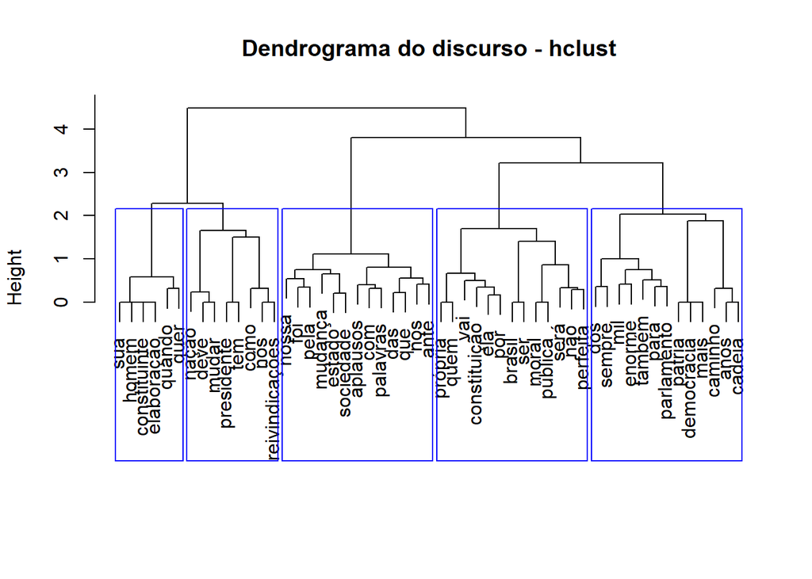

```r
# Código para o caso de querer colocar os clusters em destaque:
plot(novo_hclust, main = "Dendrograma do discurso - hclust", sub = "", xlab = "")
rect.hclust(novo_hclust, k = 5, border="blue")
```

# Referências

- https://www.curso-r.com/material/stringr/
- https://rdrr.io/rforge/tm/
- https://rpubs.com/tsholliger/301914
- https://www.learningrfordatascience.com/post/dynamic-wordclouds-with-wordcloud2/
- https://p4husp.github.io/material/textmining/
- https://p4husp.github.io/material/tutorial11/
- https://www.r-graph-gallery.com/196-the-wordcloud2-library.html
- https://cran.r-project.org/web/packages/wordcloud2/wordcloud2.pdf